# 数据探索性分析与数据预处理2-Oakland Crime Statistics

数据集：[Oakland Crime Statistics](https://www.kaggle.com/cityofoakland/oakland-crime-statistics-2011-to-2016#records-for-2015.csv)

```python
import numpy as np
import matplotlib.pyplot as plt
import matplotlib.mlab as mlab
import pandas as pd
```

## 数据预览

预览和处理2015年的数据，由于不同年份数据集处理方式类似，因此可以通过改变数据集位置对其他年份犯罪数据进行处理。

```python
data_filename="D:\\Course\\DM\\oakland-crime-statistics-2011-to-2016\\records-for-2015.csv"
dt_ord=pd.read_csv(data_filename)
dt_ord.head(3)
```

|  | Agency | Create Time | Location | Area Id | Beat | Priority | Incident Type Id | Incident Type Description | Event Number | Closed Time |
| --- | --- | --- | --- | --- | --- | --- | --- | --- | --- | --- |
| 0 | OP | 2015-01-01T00:01:59.000 | S ELMHURST AV | P3 | 31Y | 2 | 415 | DISTURBING THE PEACE | LOP150101000003 | 2015-01-01T06:23:08.000 |
| 1 | OP | 2015-01-01T00:02:02.000 | AV&D ST | P3 | 32X | 2 | 415GS | 415 GUNSHOTS | LOP150101000007 | 2015-01-01T01:44:40.000 |
| 2 | OP | 2015-01-01T00:02:06.000 | BANCROFT AV | P3 | 30Y | 2 | 933R | ALARM-RINGER | LOP150101000004 | 2015-01-01T02:12:39.000 |

```python
dt_ord.info()
```

```
<class 'pandas.core.frame.DataFrame'>
RangeIndex: 192581 entries, 0 to 192580
Data columns (total 10 columns):
 #   Column                     Non-Null Count   Dtype
---  ------                     --------------   -----
 0   Agency                     192581 non-null  object
 1   Create Time                192581 non-null  object
 2   Location                   192581 non-null  object
 3   Area Id                    192581 non-null  object
 4   Beat                       191256 non-null  object
 5   Priority                   192581 non-null  int64
 6   Incident Type Id           192581 non-null  object
 7   Incident Type Description  192338 non-null  object
 8   Event Number               192581 non-null  object
 9   Closed Time                192581 non-null  object
dtypes: int64(1), object(9)
memory usage: 14.7+ MB
```

```python
l_nominal=['Agency','Location','Area Id','Beat','Incident Type Id','Incident Type Description']
```

### 数据可视化和摘要

- 1 标称数据

```python
def num_freq(name_column,dataset):
    num=dataset[name_column].value_counts()
    num=pd.DataFrame(num)
    return num
def FreqCount(dataset):
    freq_nominal=list()
    for column in l_nominal:
        print(str(column)+ '可能的取值的频数：')
        freq_nominal.append(num_freq(column,dataset))
        print(freq_nominal[-1])
    return freq_nominal;
dt=dt_ord
freq_nom=FreqCount(dt)
```

```
Agency可能的取值的频数：
    Agency
OP  192581
Location可能的取值的频数：
                              Location
 INTERNATIONAL BLVD               3695
 AV&INTERNATIONAL BLVD            3106
 MACARTHUR BLVD                   3105
 BROADWAY                         2407
 FOOTHILL BLVD                    1753
...                                ...
21ST CIRCLE HILL DR                  1
COOLIDGE MYRTLE ST                   1
HANSOM PERALTA OAKS CT               1
MCKINLEY ST&TELEGRAPH AV             1
10TH AV&MANDANA BLVD                 1

[36515 rows x 1 columns]
Area Id可能的取值的频数：
     Area Id
P3     81629
P1     73141
P2     33423
POU     3787
PCW      595
TEC        6
Beat可能的取值的频数：
      Beat
04X   8048
08X   6874
30Y   5690
19X   5564
30X   5542
23X   5492
26Y   5449
34X   5172
06X   5056
03X   4983
07X   4910
29X   4599
```

[output cut: 61 more lines]

```
Incident Type Description可能的取值的频数：
                      Incident Type Description
ALARM-RINGER                              18181
SECURITY CHECK                            14809
STOLEN VEHICLE                             8899
911 HANG-UP                                8529
MENTALLY ILL                               8465
...                                         ...
VICE                                          1
FLOOD                                         1
NONSTUDENT REFUSE TO                          1
EXTORTION                                     1
CONSPIRACY COURT ORD                          1

[261 rows x 1 columns]
```

使用直方图对标称数据进行可视化描述。 （为数据更好的可视化效果，暂时去除频度过于小的取值）

```python
def MergeSmall(freq_nominal):
    for dataframe in freq_nominal:
        count=0
        num=0
        drop_list=list()
        print('属性：'+dataframe.columns[0])
        for i in range(0,len(dataframe)):
            if(dataframe.values[i][0]<dataframe.shape[0]*0.01 ): #忽略小于1%的
                num+=1
                count+=dataframe.values[i][0]
                drop_list.append(i)

        drop_list=sorted(drop_list, reverse=True)
        for value in drop_list:
            dataframe.drop(dataframe.index[value],inplace=True)
        print(dataframe)
        print('others( '+str(num)+')：       '+str(count))
    return freq_nominal
def MergeSmallWithoutPrint(freq_nominal):
    for dataframe in freq_nominal:
        drop_list=list()
        for i in range(0,len(dataframe)):
            if(dataframe.values[i][0]<dataframe.shape[0]*0.01 or dataframe.values[i][0]<300): #忽略小于1%的
                drop_list.append(i)
        drop_list=sorted(drop_list, reverse=True)
        for value in drop_list:
            dataframe.drop(dataframe.index[value],inplace=True)
    return freq_nominal

freq_nom=MergeSmallWithoutPrint(freq_nom)
```

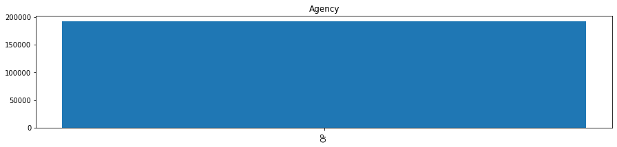

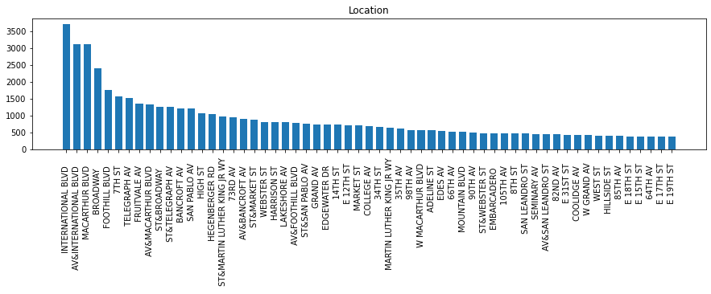

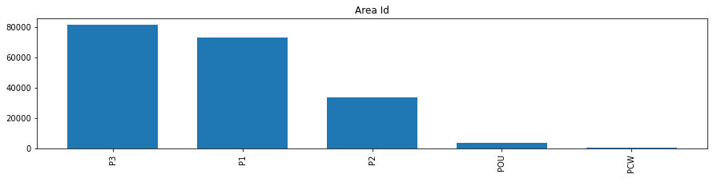

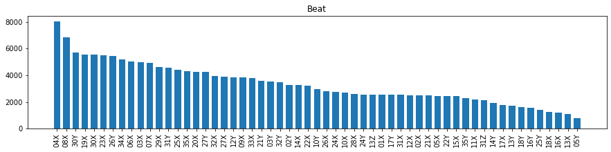

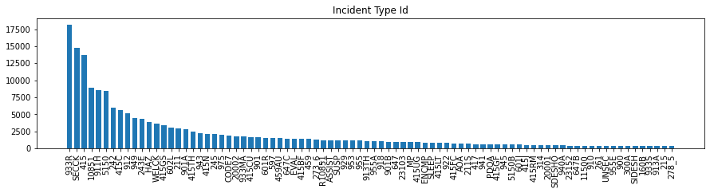

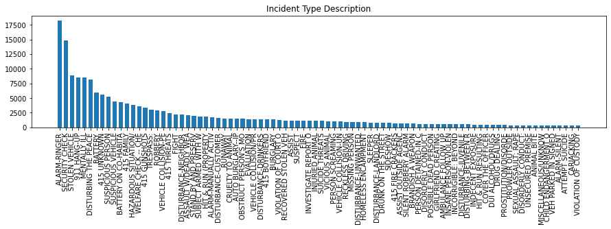

```python
def ShowHist(data_frame):
    plt.figure(figsize=(15,3))
    l_unique_data=list(data_frame.index)
    l_num=list()
    for i in data_frame.values:
        l_num.append(i[0])
    plt.bar(l_unique_data, l_num, width=0.7)
    plt.xticks(l_unique_data,rotation=90)
    plt.title(data_frame.columns[0])
    plt.show()
for data_frame in freq_nom:
    ShowHist(data_frame)
```

通过数据的可视化描述，我们可以了解到犯罪事件多发地点，比较各个地区发生犯罪事件的数量比较，从而分析个地区的安全系数等，以及犯罪事件中犯罪频率较高的事件。

- 2 数值属性 五数描述

```python
dt=dt_ord
df_num=pd.DataFrame(dt.describe())
df_num.drop(['count','mean','std'],inplace=True)
print(df_num)
null_value=dt.isnull().sum()
print('Priority 缺失值个数')
print(null_value['Priority'])
```

```
     Priority
min       0.0
25%       2.0
50%       2.0
75%       2.0
max       2.0
Priority 缺失值个数
0
```

```
array([[<matplotlib.axes._subplots.AxesSubplot object at 0x0000026249524DC8>]],
      dtype=object)
```

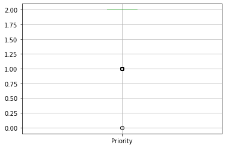

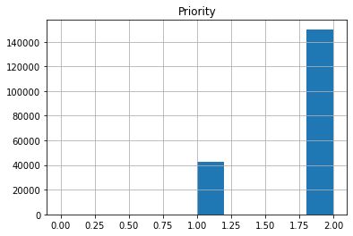

```python
dt.boxplot('Priority')
dt.hist(column='Priority')
```

## 数据缺失的处理

观察数据集中缺失数据，分析其缺失的原因。分别使用下列四种策略对缺失值进行处理:

- 将缺失部分剔除
- 用最高频率值来填补缺失值
- 通过属性的相关关系来填补缺失值
- 通过数据对象之间的相似性来填补缺失值

### 将缺失部分剔除

```python
dt1=dt_ord.dropna(axis=0,subset=['Beat'])
```

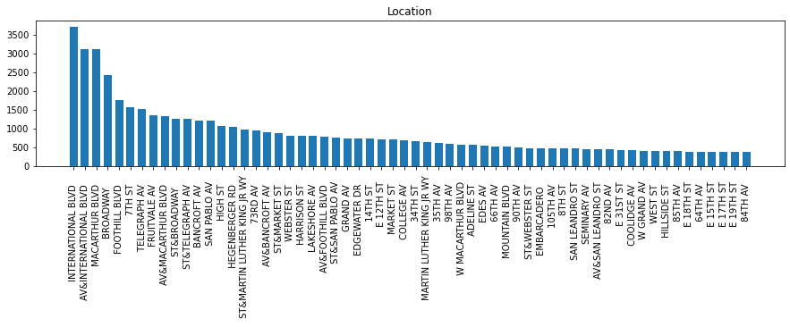

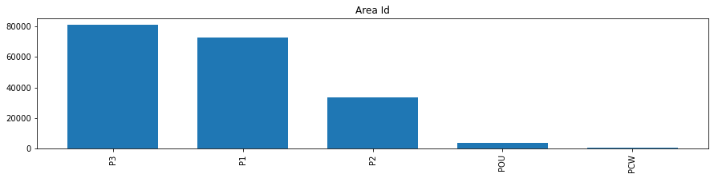

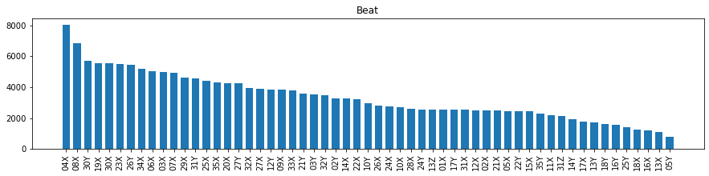

```python
l_col=['Location','Area Id','Beat']
def num_freq(name_column,dataset):
    num=dataset[name_column].value_counts()
    num=pd.DataFrame(num)
    return num
def FreqCount(dataset):
    freq_nominal=list()
    for column in l_col:
        freq_nominal.append(num_freq(column,dataset))
    return freq_nominal;
freq2=FreqCount(dt1)
freq2=MergeSmallWithoutPrint(freq2)
for data_frame in freq2:
    ShowHist(data_frame)
```

### 用最高频率值来填补缺失值

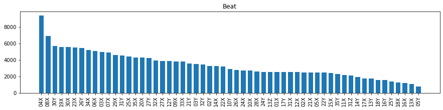

```python
dt2=dt_ord
df1=pd.DataFrame(dt2)
df1=pd.DataFrame(df1.mode())
dt2['Beat']=dt2['Beat'].fillna(df1['Beat'][0])
df=pd.DataFrame(dt2['Beat'].value_counts())
drop_list=list()
for i in range(0,len(df)):
    if(df.values[i][0]<df.shape[0]*0.01 or df.values[i][0]<300): #忽略小于1%的
        drop_list.append(i)
drop_list=sorted(drop_list, reverse=True)
for value in drop_list:
    df.drop(df.index[value],inplace=True)
ShowHist(df)
```

### 通过属性的相关关系来填补缺失值

Incident Type Description属性是对Incident Type Id的具体描述，同一事件类型id具有同样的事件类型的描述，Incident Type Description属性值为空值，可能是缺少对某些类型id的描述，因此，可将事件类型的id内容填充到描述中

```python
dt3=dt_ord
dt3=dt3[['Incident Type Id','Incident Type Description']].fillna(method='ffill',axis=1)
```

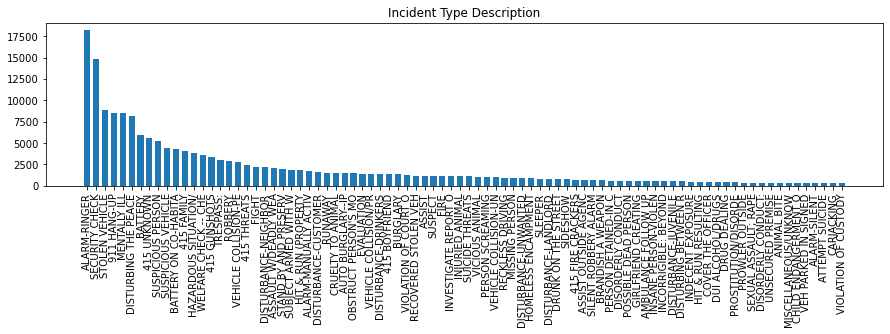

```python
df=pd.DataFrame(dt3['Incident Type Description'].value_counts())
drop_list=list()
for i in range(0,len(df)):
    if(df.values[i][0]<df.shape[0]*0.01 or df.values[i][0]<300): #忽略小于1%的
        drop_list.append(i)
drop_list=sorted(drop_list, reverse=True)
for value in drop_list:
    df.drop(df.index[value],inplace=True)
ShowHist(df)
```